# statcanR Vignette: Example 1

Thierry Warin

## Intro

In this vignette, we leverage a Statistics Canada dataset in order to demonstrate the commands available in the statcanR package and their functionality. More detailed data analyses are provided in a separate vignette.

We are interested in exploring how different organizations are succeeding in adopting sustainable practices. To do this, we begin by using the “statcan_search” command. This command allows us to match keywords related to our topic of interest with a database/ databases available on the Statistics Canada website. Given our example topic of interest, some keywords could be “green” and “business”.

#### Data identification: Using the statcan_search() command

```r
library(statcanR)
library(dplyr)
library(DT)
library(curl)
library(dplyr)
library(ggplot2)
library(reshape2)

# Search for data table with keywords
statcan_search(c("green","business"),"eng")
```

|  | title | id | description | release_date | lang |
| --- | --- | --- | --- | --- | --- |
| 1 | Barriers businesses or organizations face in adopting more green practices over the next 12 months, third quarter of 2022 | 33-10-0548-01 | Barriers businesses or organizations face in adopting more green practices over the next 12 months, by North American Industry Classification System (NAICS), business employment size, type of business… | 2022-08-30 | eng |
| 2 | Main barrier businesses or organizations face in adopting more green practices in the next 12 months | 33-10-0374-01 | Main barrier businesses or organizations face in adopting more green practices in the next 12 months, by North American Industry Classification System (NAICS), business employment size, type of busine… | 2021-08-27 | eng |
| 3 | Environmental Protection Expenditures in the Business Sector | 16F0006X | This document presents operating and capital expenditures made by primary and manufacturing industries in response to, or in anticipation of, environmental regulations and conventions. It also reports… | 2012-12-17 | eng |
| 4 | Canadian Industry's Expenditures to Reduce Greenhouse Gas Emissions | 16-001-M2008005 | This paper describes a revision of the 2002 greenhouse gas emission reduction expenditure estimates made by Canadian business. These estimates were derived from the 2002 Survey of Environmental Protec… | 2008-06-25 | eng |

We will choose the first dataset, which is on barriers that businesses or organizations face in adopting more green practices over the next 12 months, for the third quarter of 2022. Note that there is already a unique identifier available in this table. We can directly copy this identifier and paste it into the next command: “statcan_download_data”.

#### Data extraction: Using the statcan_download_data() command

```r
# Enter tableNumber and preferred language ("eng" for Enlgish or "fra" for French)
biz_barriers <- statcan_download_data(tableNumber = "33-10-0548-01",lang="eng")  %>%
  rename(potential_barriers = `Potential barriers of the business or organization when adopting more green practices over the next 12 months`) %>%

  # Remove unneeded variables
  select(-c(REF_DATE,DGUID,UOM_ID,SCALAR_FACTOR,SCALAR_ID,VECTOR,COORDINATE,SYMBOL,TERMINATED,DECIMALS))

datatable(biz_barriers, options = list(pageLength = 5))
```

|  | GEO | Business characteristics | potential_barriers | UOM | VALUE | STATUS | INDICATOR |
| --- | --- | --- | --- | --- | --- | --- | --- |
| 1 | Canada | North American Industry Classification System (NAICS), all industries | Lack of financial resources | Percent | 29.2 | A | Barriers businesses or organizations face in adopting more green practices over the next 12 months, third quarter of 2022 |
| 2 | Canada | North American Industry Classification System (NAICS), all industries | Clients are not willing to pay a higher price | Percent | 33.9 | A | Barriers businesses or organizations face in adopting more green practices over the next 12 months, third quarter of 2022 |
| 3 | Canada | North American Industry Classification System (NAICS), all industries | Time constraints or labour limitations | Percent | 24.5 | A | Barriers businesses or organizations face in adopting more green practices over the next 12 months, third quarter of 2022 |
| 4 | Canada | North American Industry Classification System (NAICS), all industries | Business or organization has industry limitations when adopting green practices | Percent | 15.1 | A | Barriers businesses or organizations face in adopting more green practices over the next 12 months, third quarter of 2022 |
| 5 | Canada | North American Industry Classification System (NAICS), all industries | Locational or on-site limitations | Percent | 8.9 | A | Barriers businesses or organizations face in adopting more green practices over the next 12 months, third quarter of 2022 |
| 6 | Canada | North American Industry Classification System (NAICS), all industries | Limited by corporate directives | Percent | 2.4 | A | Barriers businesses or organizations face in adopting more green practices over the next 12 months, third quarter of 2022 |
| 7 | Canada | North American Industry Classification System (NAICS), all industries | Metrics to measure sustainability or going green are too confusing | Percent | 4.3 | A | Barriers businesses or organizations face in adopting more green practices over the next 12 months, third quarter of 2022 |
| 8 | Canada | North American Industry Classification System (NAICS), all industries | COVID-19 | Percent | 12.3 | A | Barriers businesses or organizations face in adopting more green practices over the next 12 months, third quarter of 2022 |
| 9 | Canada | North American Industry Classification System (NAICS), all industries | Potential barriers of the business or organization when adopting more green practices over the next 12 months, other | Percent | 1.5 | A | Barriers businesses or organizations face in adopting more green practices over the next 12 months, third quarter of 2022 |
| 10 | Canada | North American Industry Classification System (NAICS), all industries | Potential barriers of the business or organization when adopting more green practices over the next 12 months, none | Percent | 40.6 | A | Barriers businesses or organizations face in adopting more green practices over the next 12 months, third quarter of 2022 |

[output cut: 9230 more lines]

## Analysis / Exploration

The first part of the analysis will concentrate on which types of organizations are unable to adopt sustainable practices due to COVID. To do this we filter for the COVID barrier and then tabulate across the different types of businesses. Furthermore, we want to only keep data that are considered acceptable to be published by Statistics Canada (i.e., those that have at least a “D” status). Finally we will examine how these adoptability values differ across Canadian provinces.

Let’s first look at how covid is preventing sustainability adoption across different industries. To do this, consider two different industries - for example, construction and finance/ insurance.

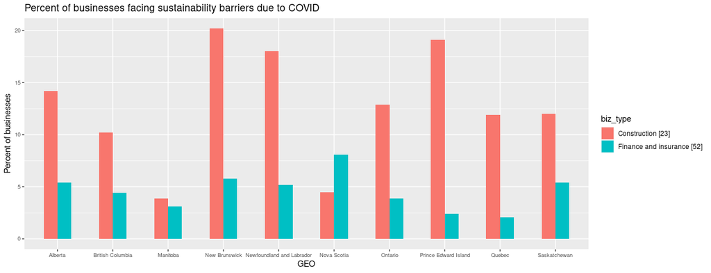

```r
# Filter for COVID barrier
covid_barrier <-biz_barriers %>%
  subset(.,potential_barriers == "COVID-19") %>%


# Filter for data status
  subset(.,STATUS == "A" | STATUS == "B" | STATUS == "C" | STATUS == "D") %>%

# Filter for province
  subset(.,GEO != "Canada" & GEO != "Nunavut" & GEO != "Northwest Territories" & GEO != "Yukon") %>%
  distinct(GEO,STATUS,`Business characteristics`, .keep_all = T)

# Construction vs fin/insr
ind_comparison <- subset(covid_barrier, `Business characteristics` == "Finance and insurance [52]"| `Business characteristics` == "Construction [23]") %>%
  mutate(biz_type = as.factor(`Business characteristics`)) %>%
  select(biz_type,GEO,VALUE)

# Plot data
ggplot2::ggplot(ind_comparison,aes(x = GEO,y = VALUE),) +
    geom_bar(aes(fill = biz_type),stat = "identity",position = "dodge", width = 0.5) +
    theme(axis.text = element_text(size = 7)) +
    ylab("Percent of businesses") +
    ggtitle("Percent of businesses facing sustainability barriers due to COVID")
```

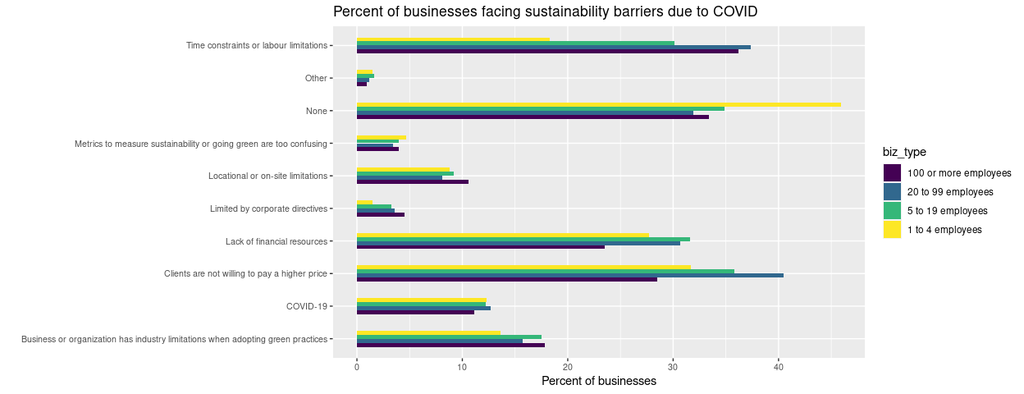

```r
biz_size <- biz_barriers %>%
  subset(.,`Business characteristics` == "1 to 4 employees" | `Business characteristics` == "5 to 19 employees" | `Business characteristics` == "20 to 99 employees" | `Business characteristics` == "100 or more employees") %>%
  subset(.,GEO == "Canada") %>%
  mutate(biz_type = as.factor(`Business characteristics`)) %>%
  mutate(biz_type = ordered(biz_type, levels = c("100 or more employees",  "20 to 99 employees", "5 to 19 employees" ,"1 to 4 employees"))) %>%
  select(biz_type, potential_barriers, VALUE)

biz_size$potential_barriers[biz_size$potential_barriers == "Potential barriers of the business or organization when adopting more green practices over the next 12 months, other"] <- "Other"
biz_size$potential_barriers[biz_size$potential_barriers == "Potential barriers of the business or organization when adopting more green practices over the next 12 months, none"] <- "None"


 ggplot(arrange(biz_size, -biz_type),aes(x = potential_barriers,y = VALUE),) +
    geom_bar(aes(fill = biz_type),stat = "identity",position = "dodge", width = 0.5) +
    theme(axis.text = element_text(size = 8)) +
    ylab("Percent of businesses") +
    xlab("") +
    coord_flip()+
    ggtitle("Percent of businesses facing sustainability barriers due to COVID")
```